# Basic descriptive stats

```r
source("reshaper.R", encoding = "UTF-8")
required_packages = c(
  "foreign",
  "magrittr",
  "PMCMR",
  "purrr",
  "RColorBrewer",
  "rcompanion",
  "stringi",
  "stringr"
)

for (package in required_packages) {
    if (!require(package, character.only=T, quietly=T)) {
        install.packages(package)
        library(package, character.only=T)
    }
}
DEF_COLOR = "lightblue"
```

Тут всякие технические моменты, не интересно.

```r
full_data = access_import_reshape("first_iter_vars.xlsx")

names(full_data) = stri_trans_general(names(full_data), "russian-latin/bgn")

full_data = map_df(full_data, as.character) #pretty shity move, i know
```

Проверим, сколько же визитов на сколько пациентов было

```r
full_data$max_visit_index = map_dbl(1:nrow(full_data),
                                    ~ full_data[.x, 282:289] %>% is.na(.) %>% `!` %>% sum())  # TODO fix hardcoded 'visit_index'es

table(full_data$max_visit_index)
```

```
##
##  1  2  3  4  5  6  7  8
## 53 31 16  9  9  6  2  1
```

Таблица “Сколько пациентов с указанным сверху числом визитов” Картинка про тоже самое:

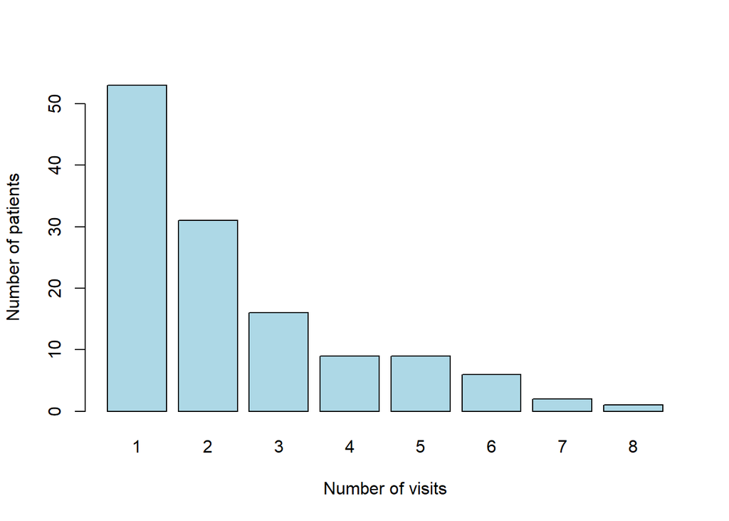

```r
barplot(
  table(full_data$max_visit_index),
  xlab = "Number of visits",
  ylab = " Number of patients",
  col = DEF_COLOR
)
```

Упс. Придется отправить 53 пациента пока в мусор, раз уж у нас проспективное исследование.

```r
cleaned_data = full_data[full_data$max_visit_index > 1, ]

cleaned_data[, str_detect(names(cleaned_data), "Data.vizita")] = apply(cleaned_data[, str_detect(names(cleaned_data), "Data.vizita")], 2, as.numeric)

cleaned_data = cleaned_data[as.numeric(cleaned_data[, 42] %>% unlist()) < 350 & !is.na(cleaned_data[, 42] %>% unlist()), ]
```

Выкинул товарищей без креатинина на первом визите и с креатининов больше 350.

Посмотрим продолжительность наблюдений

```r
cleaned_data$follow_up_length = map_dbl(
  1:nrow(cleaned_data),
  ~ cleaned_data[.x, 18:25] %>% max(., na.rm = T) %>% as.Date(., origin = "1970-01-01") -
    cleaned_data[.x, 18:25] %>% min(., na.rm = T) %>% as.Date(., origin = "1970-01-01")
)

quantile(cleaned_data$follow_up_length)
```

```
##     0%    25%    50%    75%   100%
##  29.00 185.50 287.50 489.75 698.00
```

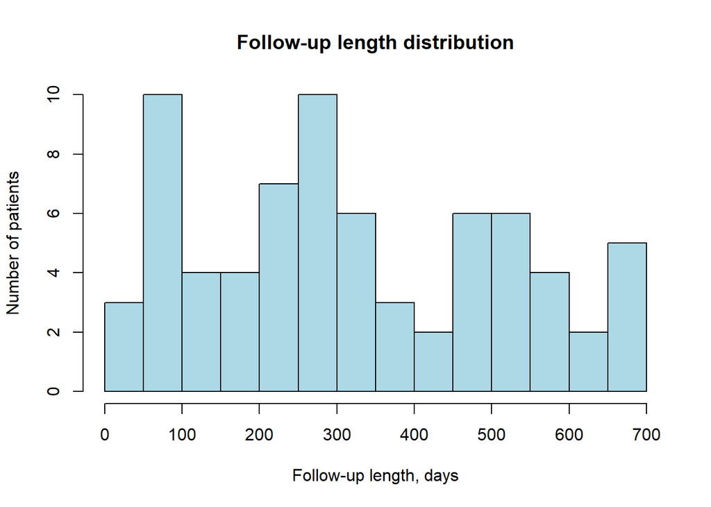

```r
hist(
  cleaned_data$follow_up_length,
  breaks = 10,
  main = "Follow-up length distribution",
  xlab = "Follow-up length, days",
  ylab = "Number of patients",
  col = DEF_COLOR
)
```

Посмотрим промежутки между визитами

```r
visits_lenth = map(8:2,
                   ~ cleaned_data[, sprintf("Data.vizita_%i", .x)] - cleaned_data[, sprintf("Data.vizita_%i", .x -
                                                                                              1)]) %>% unlist() %>% na.omit()


quantile(visits_lenth)
```

```
##    0%   25%   50%   75%  100%
##  14.0  68.5 108.0 184.0 609.0
```

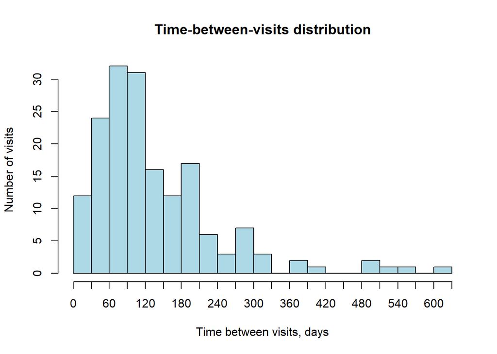

```r
hist(
  visits_lenth,
  breaks = seq(0, 630, 30),
  main = "Time-between-visits distribution",
  xlab = "Time between visits, days",
  ylab = "Number of visits",
  col = DEF_COLOR,
  axes = F
)

axis(2)
axis(1, at = seq(0, 630, 30))
```

Ладно, дальше речь вообще только о первом визите

```r
row.names(cleaned_data) = cleaned_data$patient_code
```

```r
first_visit_data = cleaned_data[, str_detect(names(cleaned_data), "_1$")]

first_visit_data$clear_drug = str_split(first_visit_data$Antikoagulyant_1, " ") %>% map(., 1) %>% unlist()

first_visit_data$clear_drug[first_visit_data$clear_drug == "Прадакса"] = "Дабигатран"

first_visit_data$clear_drug[first_visit_data$clear_drug == "Ксарелто"] = "Ривароксабан"

first_visit_data$clear_drug[first_visit_data$clear_drug == "Эликвис"] = "Апиксабан"

first_visit_data$clear_drug %<>% as.factor()
```

Антикоагулянт (Проверьте переменную! Использовалась “Эпидемиологические данные.Антикоагулянт”)

```r
table(first_visit_data$clear_drug)
```

```
##
##    Апиксабан     Варфарин   Дабигатран Ривароксабан
##           14           22           19           17
```

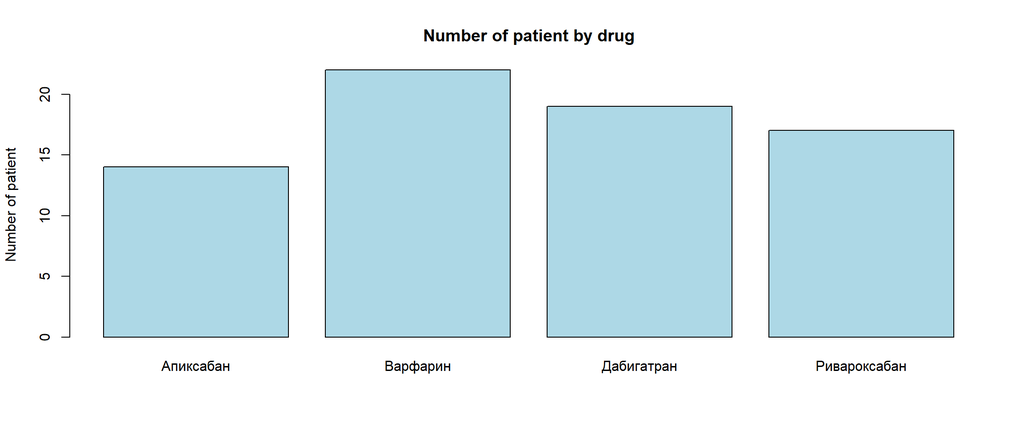

```r
barplot(
  table(first_visit_data$clear_drug),
  col = DEF_COLOR,
  main = "Number of patient by drug",
  ylab = "Number of patient"
)
```

Возраст

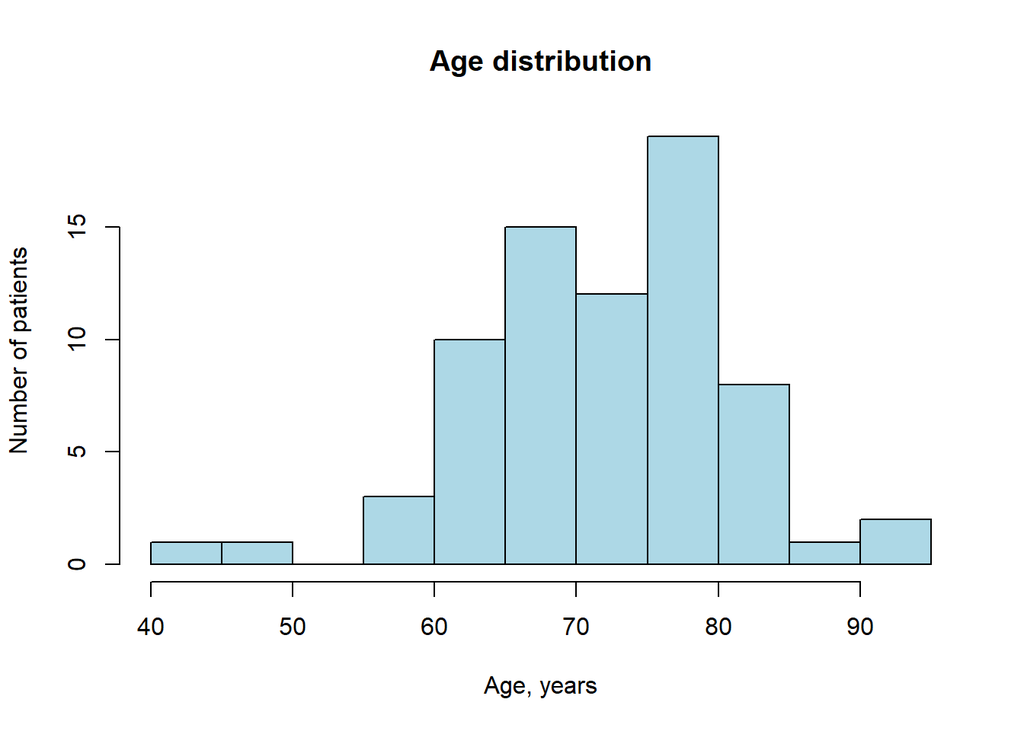

```r
first_visit_data$Polnykh.let_1 %<>% as.numeric()

hist(
  first_visit_data$Polnykh.let_1,
  col = DEF_COLOR,
  main = "Age distribution",
  xlab = "Age, years",
  ylab = "Number of patients"
)
```

```r
shapiro.test(first_visit_data$Polnykh.let_1)
```

```
##
##  Shapiro-Wilk normality test
##
## data:  first_visit_data$Polnykh.let_1
## W = 0.97576, p-value = 0.1785
```

```r
sprintf(
  "Средний возраст: %f; Среднеквадратичное отклонение: %f",
  mean(first_visit_data$Polnykh.let_1),
  sd(first_visit_data$Polnykh.let_1)
)
```

```
## [1] "Средний возраст: 72.597222; Среднеквадратичное отклонение: 8.913765"
```

По препаратам:

```r
for(i in levels(first_visit_data$clear_drug)) {
  age_vec = first_visit_data$Polnykh.let_1[first_visit_data$clear_drug == i]
  sprintf("Препарат: %s; Средний возраст: %f\u00B1%f",
          i,
          mean(age_vec),
          sd(age_vec)) %>% print()
}
```

```
## [1] "Препарат: Апиксабан; Средний возраст: 74.500000±10.839742"
## [1] "Препарат: Варфарин; Средний возраст: 73.818182±7.847574"
## [1] "Препарат: Дабигатран; Средний возраст: 69.842105±6.735174"
## [1] "Препарат: Ривароксабан; Средний возраст: 72.529412±10.536352"
```

```r
kruskal.test(first_visit_data$Polnykh.let_1~first_visit_data$clear_drug)
```

```
##
##  Kruskal-Wallis rank sum test
##
## data:  first_visit_data$Polnykh.let_1 by first_visit_data$clear_drug
## Kruskal-Wallis chi-squared = 4.3749, df = 3, p-value = 0.2237
```

Достоверных различий нет

```r
table(first_visit_data$Pol.patsiyenta_1)
```

```
##
## Жен Муж
##  42  30
```

```r
prop.table(table(first_visit_data$Pol.patsiyenta_1))
```

```
##
##       Жен       Муж
## 0.5833333 0.4166667
```

```r
table(first_visit_data$Pol.patsiyenta_1,
      first_visit_data$clear_drug)
```

```
##
##       Апиксабан Варфарин Дабигатран Ривароксабан
##   Жен         9       12          9           12
##   Муж         5       10         10            5
```

```r
prop.table(table(
  first_visit_data$Pol.patsiyenta_1,
  first_visit_data$clear_drug
),
2)
```

```
##
##       Апиксабан  Варфарин Дабигатран Ривароксабан
##   Жен 0.6428571 0.5454545  0.4736842    0.7058824
##   Муж 0.3571429 0.4545455  0.5263158    0.2941176
```

```r
fisher.test(first_visit_data$Pol.patsiyenta_1,
            first_visit_data$clear_drug)
```

```
##
##  Fisher's Exact Test for Count Data
##
## data:  first_visit_data$Pol.patsiyenta_1 and first_visit_data$clear_drug
## p-value = 0.5241
## alternative hypothesis: two.sided
```

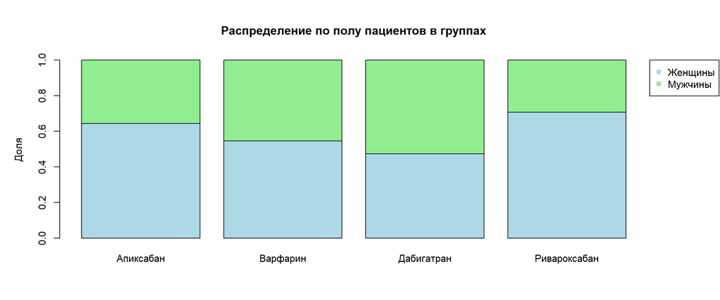

```r
par(mar = c(5, 5, 5, 6))
barplot(
  prop.table(
    table(
      first_visit_data$Pol.patsiyenta_1,
      first_visit_data$clear_drug
    ),
    2
  ),
  col = c(DEF_COLOR, "lightgreen"),
  main = "Распределение по полу пациентов в группах",
  ylab = "Доля"
)

legend(
  x = 5,
  y = 1,
  legend = c("Женщины", "Мужчины"),
  col = c(DEF_COLOR, "lightgreen"),
  pch = 15,
  xpd = TRUE,
  inset = c(-0.50, 0)
)
```

```r
table(first_visit_data$Forma.FP_1)
```

```
##
## Длительно персистирующая          Пароксизмальная           Персистирующая
##                        1                       49                        1
##               Постоянная
##                       21
```

```r
prop.table(table(first_visit_data$Forma.FP_1))
```

```
##
## Длительно персистирующая          Пароксизмальная           Персистирующая
##               0.01388889               0.68055556               0.01388889
##               Постоянная
##               0.29166667
```

```r
table(first_visit_data$Forma.FP_1, first_visit_data$clear_drug)
```

```
##
##                            Апиксабан Варфарин Дабигатран Ривароксабан
##   Длительно персистирующая         1        0          0            0
##   Пароксизмальная                 10       14         11           14
##   Персистирующая                   0        0          0            1
##   Постоянная                       3        8          8            2
```

```r
prop.table(table(first_visit_data$Forma.FP_1, first_visit_data$clear_drug),
           2)
```

```
##
##                             Апиксабан   Варфарин Дабигатран Ривароксабан
##   Длительно персистирующая 0.07142857 0.00000000 0.00000000   0.00000000
##   Пароксизмальная          0.71428571 0.63636364 0.57894737   0.82352941
##   Персистирующая           0.00000000 0.00000000 0.00000000   0.05882353
##   Постоянная               0.21428571 0.36363636 0.42105263   0.11764706
```

```r
fisher.test(first_visit_data$Forma.FP_1, first_visit_data$clear_drug)
```

```
##
##  Fisher's Exact Test for Count Data
##
## data:  first_visit_data$Forma.FP_1 and first_visit_data$clear_drug
## p-value = 0.1786
## alternative hypothesis: two.sided
```

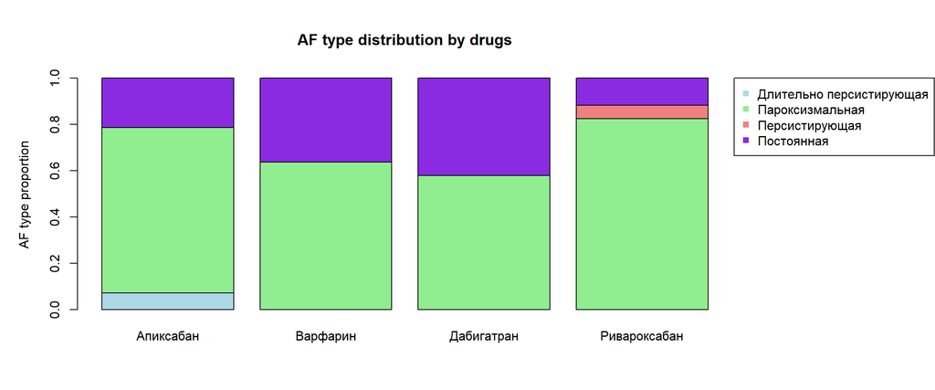

```r
par(mar = c(5, 5, 5, 13))
barplot(
  prop.table(
    table(first_visit_data$Forma.FP_1, first_visit_data$clear_drug),
    2
  ),
  col = c(DEF_COLOR, "lightgreen", "lightcoral", "blueviolet"),
  main = "AF type distribution by drugs",
  ylab = "AF type proportion"
)

legend(
  x = 5,
  y = 1,
  legend = row.names(prop.table(
    table(first_visit_data$Forma.FP_1, first_visit_data$clear_drug),
    2
  )),
  col = c(DEF_COLOR, "lightgreen", "lightcoral", "blueviolet"),
  pch = 15,
  xpd = TRUE,
  inset = c(-0.50, 0)
)
```

```r
table(first_visit_data$Ball.po.CHA2DS2VASc_1)
```

```
##
##  1  2  3  4  5  6  7  8
##  4 12 10 22 11  9  3  1
```

```r
quantile(first_visit_data$Ball.po.CHA2DS2VASc_1 %>% as.numeric())
```

```
##   0%  25%  50%  75% 100%
##    1    3    4    5    8
```

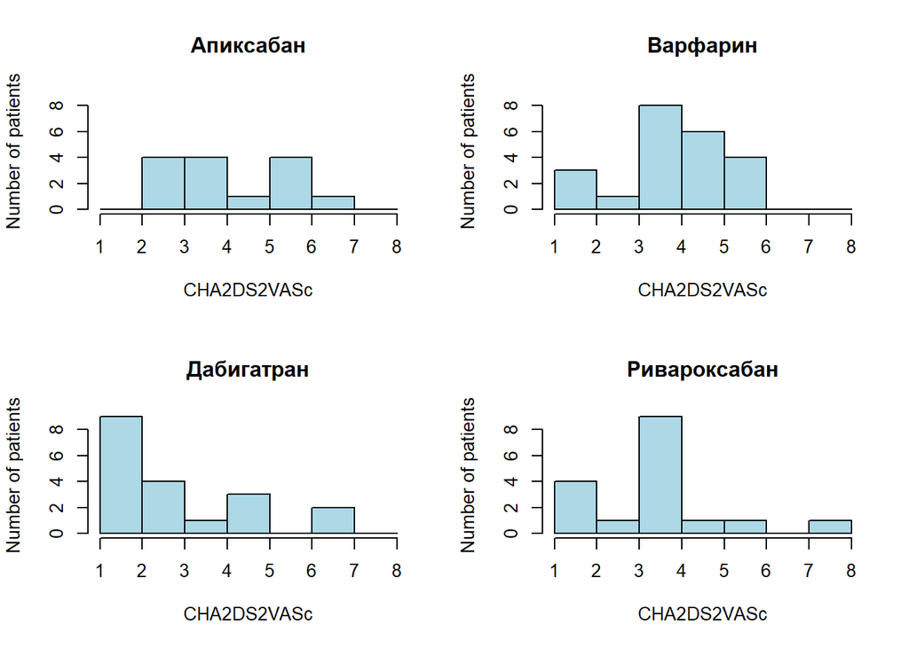

```r
par(mfrow = c(2, 2))
for (drug_name in levels(first_visit_data$clear_drug)) {
  hist(
    first_visit_data$Ball.po.CHA2DS2VASc_1[first_visit_data$clear_drug == drug_name] %>% as.numeric(.),
    breaks = 1:8,
    ylim = c(0, 9),
    col = DEF_COLOR,
    main = drug_name,
    xlab = "CHA2DS2VASc",
    ylab = "Number of patients"
  )
}
```

```r
fisher.test(first_visit_data$Ball.po.CHA2DS2VASc_1,
            first_visit_data$clear_drug,
            workspace = 2000000)
```

```
##
##  Fisher's Exact Test for Count Data
##
## data:  first_visit_data$Ball.po.CHA2DS2VASc_1 and first_visit_data$clear_drug
## p-value = 0.001845
## alternative hypothesis: two.sided
```

Тут довольно корявый пост-хок анализ. Мы не хотим баллы объединить в большие группы типа “меньше двух”, “два”, “больше трех” по примеру 10.1161/CIRCULATIONAHA.113.003628 ?

```r
pairwiseNominalIndependence(
  table(
    first_visit_data$clear_drug,
    first_visit_data$Ball.po.CHA2DS2VASc_1
  ),
  fisher = T,
  gtest = F,
  chisq = F
)
```

| Comparison | p.Fisher | p.adj.Fisher |
| --- | --- | --- |
| Апиксабан : Варфарин | 0.13700 | 0.1640 |
| Апиксабан : Дабигатран | 0.00567 | 0.0170 |
| Апиксабан : Ривароксабан | 0.07180 | 0.1080 |
| Варфарин : Дабигатран | 0.00423 | 0.0170 |
| Варфарин : Ривароксабан | 0.38000 | 0.3800 |
| Дабигатран : Ривароксабан | 0.01090 | 0.0218 |

Попробуем категоризовать chads

```r
first_visit_data$Ball.po.CHA2DS2VASc_1 %<>% as.numeric()

first_visit_data$chads_cat = map_chr(first_visit_data$Ball.po.CHA2DS2VASc_1, ~
{
  if (.x < 2) {
    "<2"
  } else if (.x == 2) {
    "2"
  } else{
    "2<"
  }
})

first_visit_data$chads_cat %<>% as.factor(.)

levels(first_visit_data$chads_cat) = c("<2", "2", ">2")
```

```r
table(first_visit_data$clear_drug, first_visit_data$chads_cat)
```

```
##
##                <2  2 >2
##   Апиксабан     0  0 14
##   Варфарин      1  2 19
##   Дабигатран    2  7 10
##   Ривароксабан  1  3 13
```

```r
fisher.test(first_visit_data$clear_drug, first_visit_data$chads_cat)
```

```
##
##  Fisher's Exact Test for Count Data
##
## data:  first_visit_data$clear_drug and first_visit_data$chads_cat
## p-value = 0.03637
## alternative hypothesis: two.sided
```

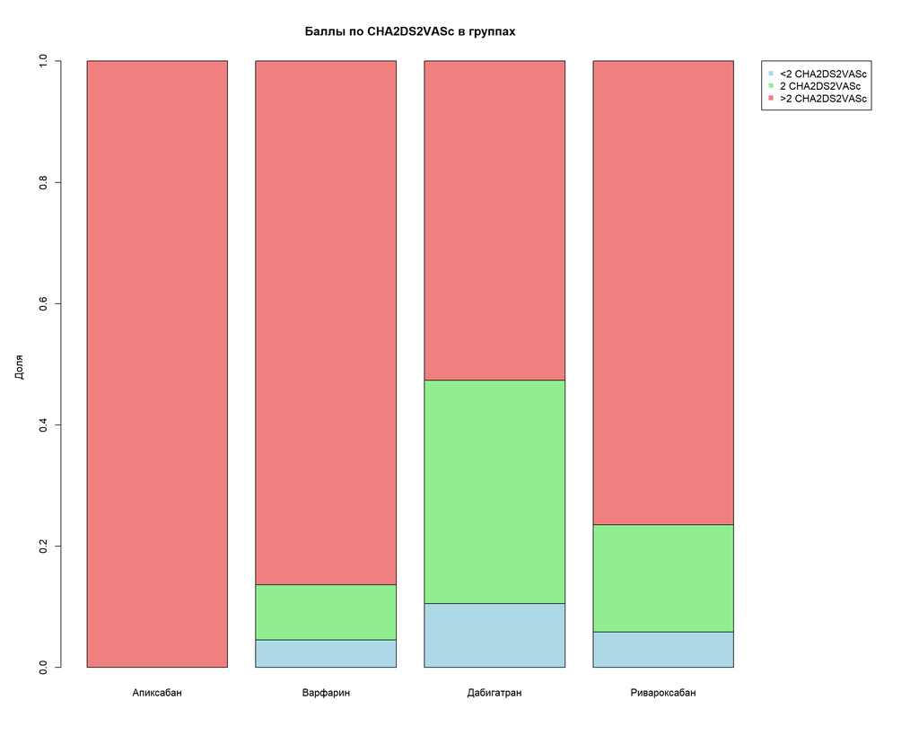

```r
par(mar = c(5, 5, 5, 13))
barplot(
  prop.table(
    table(first_visit_data$chads_cat, first_visit_data$clear_drug),
    2
  ),
  col = c(DEF_COLOR, "lightgreen", "lightcoral"),
  main = "Баллы по CHA2DS2VASc в группах",
  ylab = "Доля"
)

legend(
  x = 5,
  y = 1,
  legend = c("<2 CHA2DS2VASc", "2 CHA2DS2VASc", ">2 CHA2DS2VASc"),
  col = c(DEF_COLOR, "lightgreen", "lightcoral"),
  pch = 15,
  xpd = TRUE,
  inset = c(-0.50, 0)
)
```

```r
pairwiseNominalIndependence(
  table(first_visit_data$clear_drug, first_visit_data$chads_cat),
  fisher = T,
  gtest = F,
  chisq = F
)
```

| Comparison | p.Fisher | p.adj.Fisher |
| --- | --- | --- |
| Апиксабан : Варфарин | 0.69800 | 0.8150 |
| Апиксабан : Дабигатран | 0.00435 | 0.0261 |
| Апиксабан : Ривароксабан | 0.23200 | 0.4640 |
| Варфарин : Дабигатран | 0.05620 | 0.1690 |
| Варфарин : Ривароксабан | 0.81500 | 0.8150 |
| Дабигатран : Ривароксабан | 0.38200 | 0.5730 |

Ну, кажется, прадакса от эликвиса отличается даже по скорректированному р-value. Перейдем к HAS-BLED

```r
first_visit_data$Ball.po.HAS.BLED_1 %<>% as.numeric()
```

```r
table(first_visit_data$Ball.po.HAS.BLED_1)
```

```
##
##  0  1  2  3  4
##  6 29 28  8  1
```

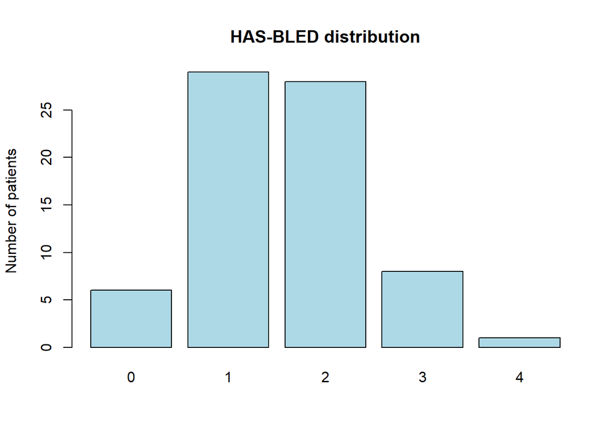

```r
barplot(first_visit_data$Ball.po.HAS.BLED_1 %>% table(),
        col = DEF_COLOR,
        ylab = "Number of patients",
        main = "HAS-BLED distribution")
```

```r
table(first_visit_data$Ball.po.HAS.BLED_1, first_visit_data$clear_drug)
```

```
##
##     Апиксабан Варфарин Дабигатран Ривароксабан
##   0         1        0          4            1
##   1         3        7          9           10
##   2         7       12          5            4
##   3         2        3          1            2
##   4         1        0          0            0
```

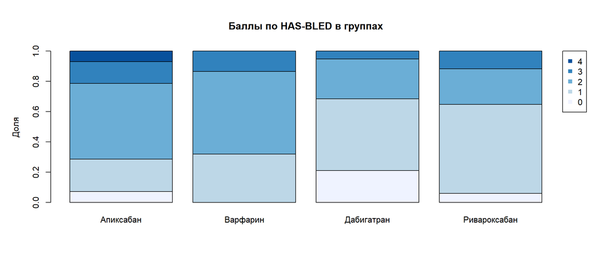

```r
par(mar = c(5, 5, 5, 5))

barplot(
  table(
    first_visit_data$Ball.po.HAS.BLED_1,
    first_visit_data$clear_drug
  ) %>% prop.table(., 2),
  col = brewer.pal(n = first_visit_data$Ball.po.HAS.BLED_1 %>% unique() %>% length, "Blues"),
  main = "Баллы по HAS-BLED в группах",
  ylab = "Доля"
)
legend(
  x = 5,
  y = 1,
  legend = 4:0,
  col = brewer.pal(n = first_visit_data$Ball.po.HAS.BLED_1 %>% unique() %>% length, "Blues") %>% rev(),
  pch = 15,
  xpd = TRUE,
  inset = c(-0.50, 0)
)
```

```r
pairwiseNominalIndependence(
  table(
    first_visit_data$clear_drug,
    first_visit_data$Ball.po.HAS.BLED_1
  ),
  fisher = T,
  gtest = F,
  chisq = F
)
```

| Comparison | p.Fisher | p.adj.Fisher |
| --- | --- | --- |
| Апиксабан : Варфарин | 0.560 | 0.590 |
| Апиксабан : Дабигатран | 0.222 | 0.333 |
| Апиксабан : Ривароксабан | 0.203 | 0.333 |
| Варфарин : Дабигатран | 0.046 | 0.276 |
| Варфарин : Ривароксабан | 0.142 | 0.333 |
| Дабигатран : Ривароксабан | 0.590 | 0.590 |

Тут вроде все нормально. Займемся креатинином и компанией

```r
names(first_visit_data)[6] = "creatinine"

first_visit_data$creatinine %<>% as.numeric()
```

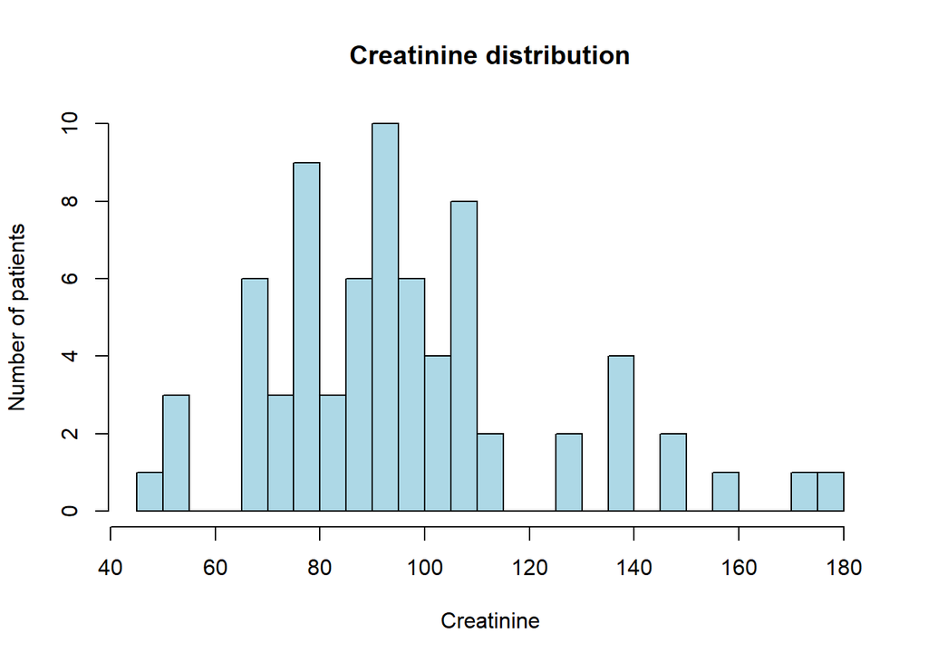

```r
hist(first_visit_data$creatinine,
     col = DEF_COLOR,
     breaks = 20,
     xlab = "Creatinine",
     ylab = "Number of patients",
     main = "Creatinine distribution")
```

```r
shapiro.test(first_visit_data$creatinine)
```

```
##
##  Shapiro-Wilk normality test
##
## data:  first_visit_data$creatinine
## W = 0.93531, p-value = 0.001109
```

```r
quantile(first_visit_data$creatinine, na.rm = T)
```

```
##      0%     25%     50%     75%    100%
##  48.620  77.570  94.145 106.775 179.000
```

```r
kruskal.test(first_visit_data$creatinine~first_visit_data$clear_drug)
```

```
##
##  Kruskal-Wallis rank sum test
##
## data:  first_visit_data$creatinine by first_visit_data$clear_drug
## Kruskal-Wallis chi-squared = 5.6632, df = 3, p-value = 0.1292
```

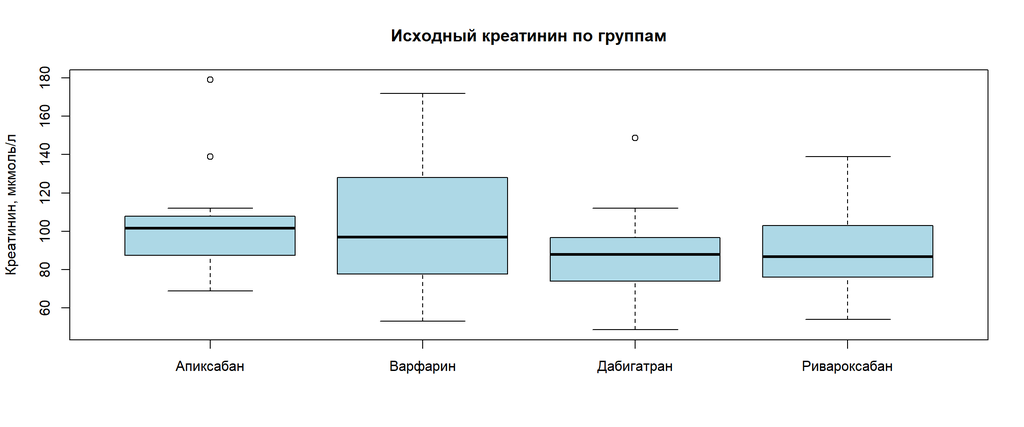

```r
boxplot(first_visit_data$creatinine~first_visit_data$clear_drug,
        ylab = "Креатинин, мкмоль/л",
        main = "Исходный креатинин по группам",
        col = DEF_COLOR)
```

Не отличались, и слава богу.

СКФ

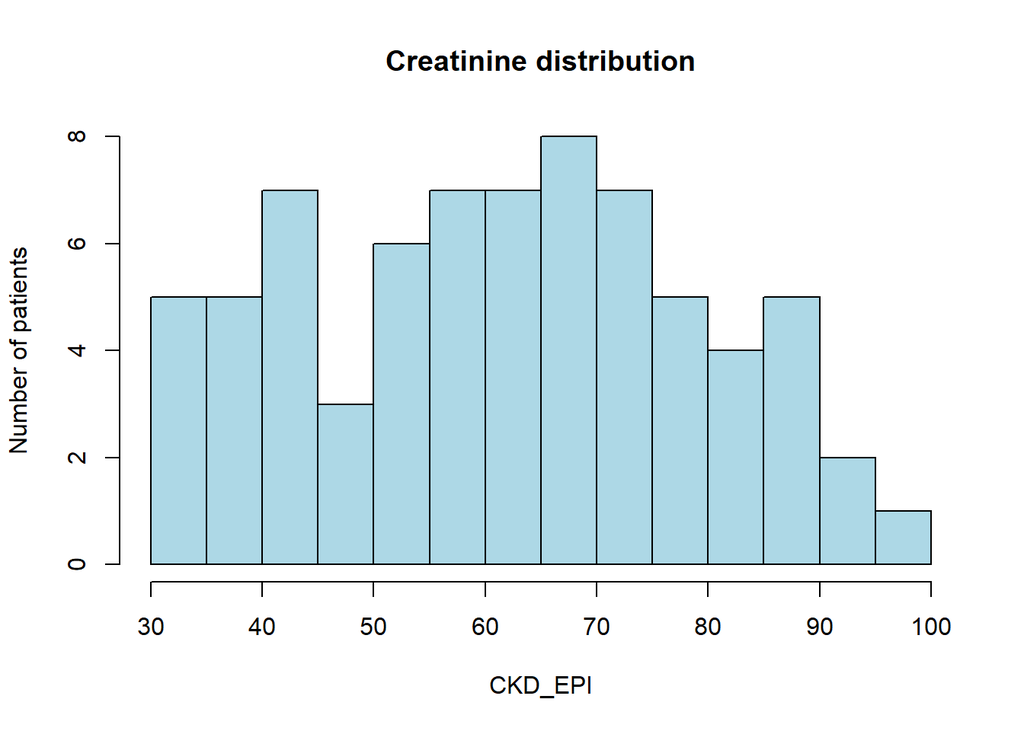

```r
first_visit_data$SKF.CKD.EPI_1 %<>% as.numeric()

hist(first_visit_data$SKF.CKD.EPI_1,
     col = DEF_COLOR,
     breaks = 20,
     xlab = "CKD_EPI",
     ylab = "Number of patients",
     main = "Creatinine distribution")
```

```r
shapiro.test(first_visit_data$SKF.CKD.EPI_1)
```

```
##
##  Shapiro-Wilk normality test
##
## data:  first_visit_data$SKF.CKD.EPI_1
## W = 0.97172, p-value = 0.1044
```

```r
sprintf(
  "Средний CKD-EPI: %f; Среднеквадратичное отклонение: %f",
  mean(first_visit_data$SKF.CKD.EPI_1, na.rm = T),
  sd(first_visit_data$SKF.CKD.EPI_1, na.rm = T)
)
```

```
## [1] "Средний CKD-EPI: 61.470416; Среднеквадратичное отклонение: 17.107526"
```

По препаратам:

```r
for(i in levels(first_visit_data$clear_drug)) {
  creat_vec = first_visit_data$SKF.CKD.EPI_1[first_visit_data$clear_drug == i]
  sprintf("Препарат: %s; Средний CKD-EPI: %f\u00B1%f",
          i,
          mean(creat_vec, na.rm = T),
          sd(creat_vec, na.rm = T)) %>% print()
}
```

```
## [1] "Препарат: Апиксабан; Средний CKD-EPI: 53.385714±15.050574"
## [1] "Препарат: Варфарин; Средний CKD-EPI: 58.016818±18.377712"
## [1] "Препарат: Дабигатран; Средний CKD-EPI: 69.915789±13.974709"
## [1] "Препарат: Ривароксабан; Средний CKD-EPI: 63.158824±17.039881"
```

```r
kruskal.test(first_visit_data$SKF.CKD.EPI_1~first_visit_data$clear_drug)
```

```
##
##  Kruskal-Wallis rank sum test
##
## data:  first_visit_data$SKF.CKD.EPI_1 by first_visit_data$clear_drug
## Kruskal-Wallis chi-squared = 9.406, df = 3, p-value = 0.02435
```

```r
pairwise.wilcox.test(first_visit_data$SKF.CKD.EPI_1, first_visit_data$clear_drug)
```

```
##
##  Pairwise comparisons using Wilcoxon rank sum test
##
## data:  first_visit_data$SKF.CKD.EPI_1 and first_visit_data$clear_drug
##
##              Апиксабан Варфарин Дабигатран
## Варфарин     0.745     -        -
## Дабигатран   0.025     0.081    -
## Ривароксабан 0.683     0.745    0.723
##
## P value adjustment method: holm
```

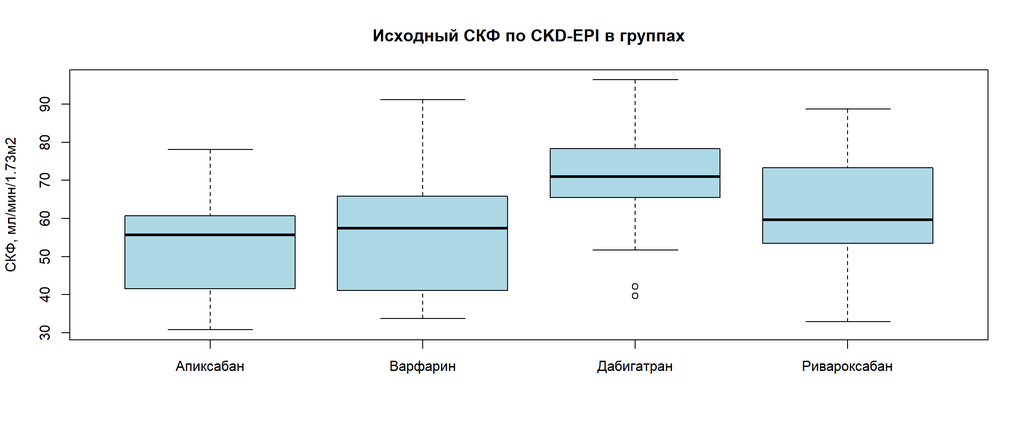

```r
boxplot(first_visit_data$SKF.CKD.EPI_1~first_visit_data$clear_drug,
        ylab = "СКФ, мл/мин/1.73м2",
        main = "Исходный СКФ по CKD-EPI в группах",
        col = DEF_COLOR)
```

У вас опять прадакса с эликвисом отличаются.

Клиренс

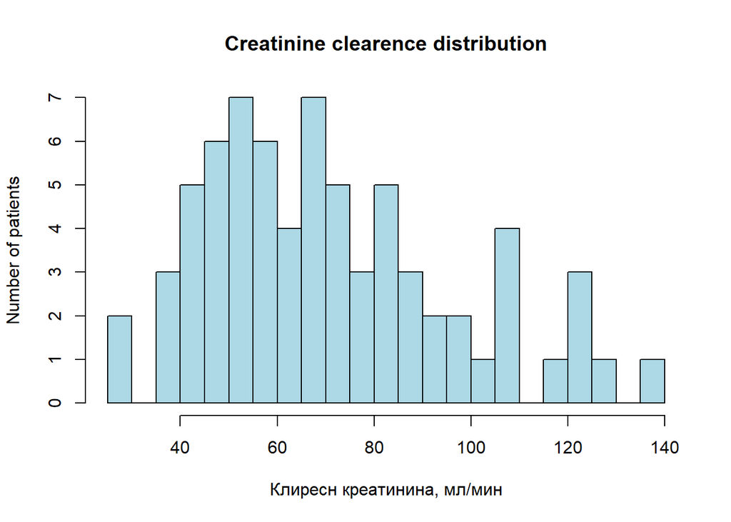

```r
first_visit_data$KK.Kokrofta.Golta_1 %<>% as.numeric()

hist(first_visit_data$KK.Kokrofta.Golta_1,
     col = DEF_COLOR,
     breaks = 20,
     xlab = "Клиресн креатинина, мл/мин",
     ylab = "Number of patients",
     main = "Creatinine clearence distribution")
```

```r
shapiro.test(first_visit_data$KK.Kokrofta.Golta_1)
```

```
##
##  Shapiro-Wilk normality test
##
## data:  first_visit_data$KK.Kokrofta.Golta_1
## W = 0.95369, p-value = 0.01059
```

```r
quantile(first_visit_data$KK.Kokrofta.Golta_1, na.rm = T)
```

```
##      0%     25%     50%     75%    100%
##  26.130  52.255  65.960  85.235 137.070
```

По препаратам:

```r
for(i in levels(first_visit_data$clear_drug)) {
  print(i)
  print(quantile(first_visit_data$KK.Kokrofta.Golta_1[first_visit_data$clear_drug == i], na.rm = T))
}
```

```
## [1] "Апиксабан"
##       0%      25%      50%      75%     100%
##  26.1300  43.9775  55.9350  78.8750 123.2000
## [1] "Варфарин"
##       0%      25%      50%      75%     100%
##  29.7900  47.8475  58.3250  69.3750 121.5200
## [1] "Дабигатран"
##     0%    25%    50%    75%   100%
##  53.88  67.09  80.77  98.74 128.05
## [1] "Ривароксабан"
##       0%      25%      50%      75%     100%
##  36.5800  51.2850  64.1350  86.7325 137.0700
```

```r
kruskal.test(first_visit_data$KK.Kokrofta.Golta_1~first_visit_data$clear_drug)
```

```
##
##  Kruskal-Wallis rank sum test
##
## data:  first_visit_data$KK.Kokrofta.Golta_1 by first_visit_data$clear_drug
## Kruskal-Wallis chi-squared = 10.797, df = 3, p-value = 0.01288
```

```r
pairwise.wilcox.test(first_visit_data$KK.Kokrofta.Golta_1, first_visit_data$clear_drug)
```

```
##
##  Pairwise comparisons using Wilcoxon rank sum test
##
## data:  first_visit_data$KK.Kokrofta.Golta_1 and first_visit_data$clear_drug
##
##              Апиксабан Варфарин Дабигатран
## Варфарин     1.000     -        -
## Дабигатран   0.062     0.007    -
## Ривароксабан 1.000     1.000    0.466
##
## P value adjustment method: holm
```

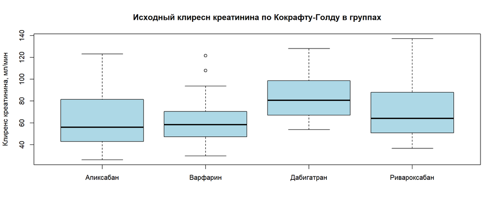

```r
boxplot(first_visit_data$KK.Kokrofta.Golta_1~first_visit_data$clear_drug,
        ylab = "Клиренс креатинина, мл/мин",
        main = "Исходный клиресн креатинина по Кокрафту-Голду в группах",
        col = DEF_COLOR)
```

Тут тоже чть различия между прадаксой и варфарином.

### Теперь прочие параметры коротко

ГБ

```r
first_visit_data$GB_1 %>% table(., first_visit_data$clear_drug) %T>% print() %>% prop.table(., 2)
```

```
##
## .       Апиксабан Варфарин Дабигатран Ривароксабан
##   FALSE         0        1          1            0
##   TRUE         14       21         18           17
```

```
##
## .        Апиксабан   Варфарин Дабигатран Ривароксабан
##   FALSE 0.00000000 0.04545455 0.05263158   0.00000000
##   TRUE  1.00000000 0.95454545 0.94736842   1.00000000
```

```r
fisher.test(first_visit_data$clear_drug, first_visit_data$GB_1)
```

```
##
##  Fisher's Exact Test for Count Data
##
## data:  first_visit_data$clear_drug and first_visit_data$GB_1
## p-value = 1
## alternative hypothesis: two.sided
```

Неконтроллируемая ГБ

```r
first_visit_data$Nekontroliruyemaya.GB_1 %>% table(., first_visit_data$clear_drug) %T>% print() %>% prop.table(., 2)
```

```
##
## .       Апиксабан Варфарин Дабигатран Ривароксабан
##   FALSE        14       22         19           17
```

```
##
## .       Апиксабан Варфарин Дабигатран Ривароксабан
##   FALSE         1        1          1            1
```

```r
fisher.test(first_visit_data$clear_drug, first_visit_data$GB_1)
```

```
##
##  Fisher's Exact Test for Count Data
##
## data:  first_visit_data$clear_drug and first_visit_data$GB_1
## p-value = 1
## alternative hypothesis: two.sided
```

Сахарный диабет

```r
first_visit_data$SD_1 %>% table(., first_visit_data$clear_drug) %T>% print() %>% prop.table(., 2)
```

```
##
## .       Апиксабан Варфарин Дабигатран Ривароксабан
##   FALSE        10       17         14           14
##   TRUE          4        5          5            3
```

```
##
## .       Апиксабан  Варфарин Дабигатран Ривароксабан
##   FALSE 0.7142857 0.7727273  0.7368421    0.8235294
##   TRUE  0.2857143 0.2272727  0.2631579    0.1764706
```

```r
fisher.test(first_visit_data$clear_drug, first_visit_data$SD_1)
```

```
##
##  Fisher's Exact Test for Count Data
##
## data:  first_visit_data$clear_drug and first_visit_data$SD_1
## p-value = 0.9112
## alternative hypothesis: two.sided
```

Хсн

```r
first_visit_data$KHSN_1 %>% table(., first_visit_data$clear_drug) %T>% print() %>% prop.table(., 2)
```

```
##
## .       Апиксабан Варфарин Дабигатран Ривароксабан
##   FALSE        13       19         15           17
##   TRUE          1        3          4            0
```

```
##
## .        Апиксабан   Варфарин Дабигатран Ривароксабан
##   FALSE 0.92857143 0.86363636 0.78947368   1.00000000
##   TRUE  0.07142857 0.13636364 0.21052632   0.00000000
```

```r
fisher.test(first_visit_data$clear_drug, first_visit_data$KHSN_1)
```

```
##
##  Fisher's Exact Test for Count Data
##
## data:  first_visit_data$clear_drug and first_visit_data$KHSN_1
## p-value = 0.2305
## alternative hypothesis: two.sided
```

Курение

```r
first_visit_data$Kureniye_1 %>% table(., first_visit_data$clear_drug) %T>% print() %>% prop.table(., 2)
```

```
##
## .       Апиксабан Варфарин Дабигатран Ривароксабан
##   FALSE        14       21         19           15
##   TRUE          0        1          0            2
```

```
##
## .        Апиксабан   Варфарин Дабигатран Ривароксабан
##   FALSE 1.00000000 0.95454545 1.00000000   0.88235294
##   TRUE  0.00000000 0.04545455 0.00000000   0.11764706
```

```r
fisher.test(first_visit_data$clear_drug, first_visit_data$Kureniye_1)
```

```
##
##  Fisher's Exact Test for Count Data
##
## data:  first_visit_data$clear_drug and first_visit_data$Kureniye_1
## p-value = 0.3624
## alternative hypothesis: two.sided
```

ИБС

```r
first_visit_data$IBS_1 %>% table(., first_visit_data$clear_drug) %T>% print() %>% prop.table(., 2)
```

```
##
## .       Апиксабан Варфарин Дабигатран Ривароксабан
##   FALSE         8       11         14           12
##   TRUE          6       11          5            5
```

```
##
## .       Апиксабан  Варфарин Дабигатран Ривароксабан
##   FALSE 0.5714286 0.5000000  0.7368421    0.7058824
##   TRUE  0.4285714 0.5000000  0.2631579    0.2941176
```

```r
fisher.test(first_visit_data$clear_drug, first_visit_data$IBS_1)
```

```
##
##  Fisher's Exact Test for Count Data
##
## data:  first_visit_data$clear_drug and first_visit_data$IBS_1
## p-value = 0.3988
## alternative hypothesis: two.sided
```

Сосудистые заболевания

```r
first_visit_data$Sosudistyye.zabolevaniya_1 %>% table(., first_visit_data$clear_drug) %T>% print() %>% prop.table(., 2)
```

```
##
## .       Апиксабан Варфарин Дабигатран Ривароксабан
##   FALSE         8        7         14           12
##   TRUE          6       15          5            5
```

```
##
## .       Апиксабан  Варфарин Дабигатран Ривароксабан
##   FALSE 0.5714286 0.3181818  0.7368421    0.7058824
##   TRUE  0.4285714 0.6818182  0.2631579    0.2941176
```

```r
fisher.test(first_visit_data$clear_drug, first_visit_data$Sosudistyye.zabolevaniya_1)
```

```
##
##  Fisher's Exact Test for Count Data
##
## data:  first_visit_data$clear_drug and first_visit_data$Sosudistyye.zabolevaniya_1
## p-value = 0.02965
## alternative hypothesis: two.sided
```

```r
pairwiseNominalIndependence(
  table(
    first_visit_data$clear_drug,
    first_visit_data$Sosudistyye.zabolevaniya_1
  ),
  fisher = T,
  gtest = F,
  chisq = F
)
```

| Comparison | p.Fisher | p.adj.Fisher |
| --- | --- | --- |
| Апиксабан : Варфарин | 0.1750 | 0.3500 |
| Апиксабан : Дабигатран | 0.4590 | 0.5720 |
| Апиксабан : Ривароксабан | 0.4770 | 0.5720 |
| Варфарин : Дабигатран | 0.0122 | 0.0732 |
| Варфарин : Ривароксабан | 0.0248 | 0.0744 |
| Дабигатран : Ривароксабан | 1.0000 | 1.0000 |

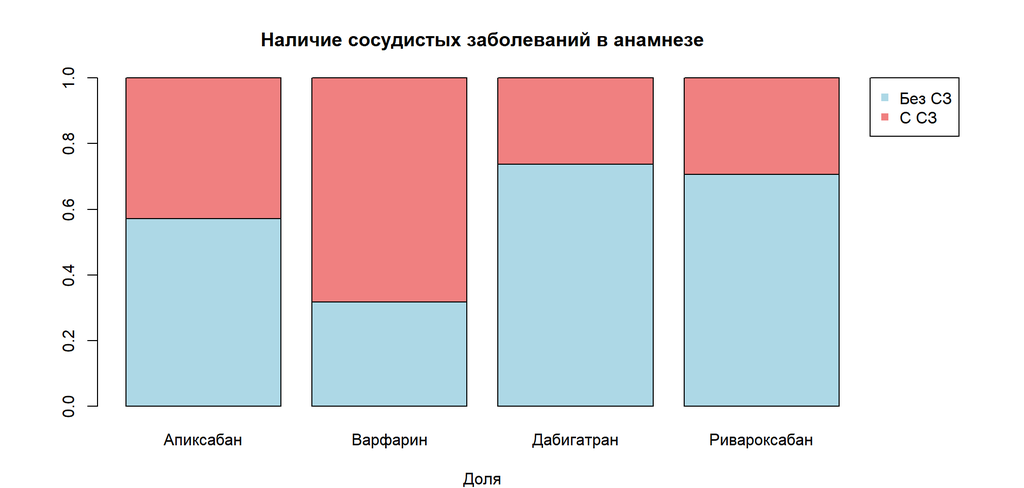

```r
par(mar = c(4,5,4,8))

barplot(
  prop.table(
    table(
      first_visit_data$Sosudistyye.zabolevaniya_1,
      first_visit_data$clear_drug
    ),
    2
  ),
  col = c(DEF_COLOR, "lightcoral"),
  main = "Наличие сосудистых заболеваний в анамнезе",
  xlab = "Доля"
)

legend(
  x = 5,
  y = 1,
  legend = c("Без СЗ", "С СЗ"),
  col = c(DEF_COLOR, "lightcoral"),
  pch = 15,
  xpd = TRUE,
  inset = c(-0.50, 0)
)
```

ЯБЖ

```r
first_visit_data$YABZH.DPK_1 %>% table(., first_visit_data$clear_drug) %T>% print() %>% prop.table(., 2)
```

```
##
## .       Апиксабан Варфарин Дабигатран Ривароксабан
##   FALSE        11       18         16           15
##   TRUE          3        4          3            2
```

```
##
## .       Апиксабан  Варфарин Дабигатран Ривароксабан
##   FALSE 0.7857143 0.8181818  0.8421053    0.8823529
##   TRUE  0.2142857 0.1818182  0.1578947    0.1176471
```

```r
fisher.test(first_visit_data$clear_drug, first_visit_data$YABZH.DPK_1)
```

```
##
##  Fisher's Exact Test for Count Data
##
## data:  first_visit_data$clear_drug and first_visit_data$YABZH.DPK_1
## p-value = 0.9234
## alternative hypothesis: two.sided
```

МКБ

```r
first_visit_data$MKB_1 %>% table(., first_visit_data$clear_drug) %T>% print() %>% prop.table(., 2)
```

```
##
## .       Апиксабан Варфарин Дабигатран Ривароксабан
##   FALSE        14       17         18           15
##   TRUE          0        5          1            2
```

```
##
## .        Апиксабан   Варфарин Дабигатран Ривароксабан
##   FALSE 1.00000000 0.77272727 0.94736842   0.88235294
##   TRUE  0.00000000 0.22727273 0.05263158   0.11764706
```

```r
fisher.test(first_visit_data$clear_drug, first_visit_data$MKB_1)
```

```
##
##  Fisher's Exact Test for Count Data
##
## data:  first_visit_data$clear_drug and first_visit_data$MKB_1
## p-value = 0.1792
## alternative hypothesis: two.sided
```

```r
first_visit_data$Alkogolizm_1 %>% table(., first_visit_data$clear_drug) %T>% print() %>% prop.table(., 2)
```

```
##
## .       Апиксабан Варфарин Дабигатран Ривароксабан
##   FALSE        14       22         19           17
```

```
##
## .       Апиксабан Варфарин Дабигатран Ривароксабан
##   FALSE         1        1          1            1
```

```r
# fisher.test(first_visit_data$clear_drug, first_visit_data$MKB_1)
```

Алкоголизм

```r
first_visit_data$Alkogolizm_1 %>% table(., first_visit_data$clear_drug) %T>% print() %>% prop.table(., 2)
```

```
##
## .       Апиксабан Варфарин Дабигатран Ривароксабан
##   FALSE        14       22         19           17
```

```
##
## .       Апиксабан Варфарин Дабигатран Ривароксабан
##   FALSE         1        1          1            1
```

```r
# fisher.test(first_visit_data$clear_drug, first_visit_data$MKB_1)
```

Амиодарон

```r
first_visit_data$Amiodaron_1[is.na(first_visit_data$Amiodaron_1)] = "Нет"
first_visit_data$Amiodaron_1 %>% table(., first_visit_data$clear_drug) %T>% print() %>% prop.table(., 2)
```

```
##
## .           Апиксабан Варфарин Дабигатран Ривароксабан
##   Амиодарон         0        2          0            0
##   Кордарон          3        1          2            3
##   Нет              11       19         17           14
```

```
##
## .            Апиксабан   Варфарин Дабигатран Ривароксабан
##   Амиодарон 0.00000000 0.09090909 0.00000000   0.00000000
##   Кордарон  0.21428571 0.04545455 0.10526316   0.17647059
##   Нет       0.78571429 0.86363636 0.89473684   0.82352941
```

```r
fisher.test(first_visit_data$clear_drug, first_visit_data$Amiodaron_1)
```

```
##
##  Fisher's Exact Test for Count Data
##
## data:  first_visit_data$clear_drug and first_visit_data$Amiodaron_1
## p-value = 0.4114
## alternative hypothesis: two.sided
```

Аспирин

```r
first_visit_data$Aspirin_1[is.na(first_visit_data$Aspirin_1)] = "Нет"
first_visit_data$Aspirin_1 %>% table(., first_visit_data$clear_drug) %T>% print() %>% prop.table(., 2)
```

```
##
## .                           Апиксабан Варфарин Дабигатран Ривароксабан
##   Ацетилсалициловая кислота         0        0          0            1
##   Нет                              14       21         19           16
##   ТромбоАсс                         0        1          0            0
```

```
##
## .                            Апиксабан   Варфарин Дабигатран Ривароксабан
##   Ацетилсалициловая кислота 0.00000000 0.00000000 0.00000000   0.05882353
##   Нет                       1.00000000 0.95454545 1.00000000   0.94117647
##   ТромбоАсс                 0.00000000 0.04545455 0.00000000   0.00000000
```

```r
fisher.test(first_visit_data$clear_drug, first_visit_data$Aspirin_1)
```

```
##
##  Fisher's Exact Test for Count Data
##
## data:  first_visit_data$clear_drug and first_visit_data$Aspirin_1
## p-value = 0.7461
## alternative hypothesis: two.sided
```

Другие антиагреганты

```r
first_visit_data$Drugiye.antiagreganty_1[is.na(first_visit_data$Drugiye.antiagreganty_1)] = "Нет"
first_visit_data$Drugiye.antiagreganty_1 %>% table(., first_visit_data$clear_drug) %T>% print() %>% prop.table(., 2)
```

```
##
## .              Апиксабан Варфарин Дабигатран Ривароксабан
##   Клопидогрель         2        0          0            1
##   Нет                 12       22         19           16
```

```
##
## .               Апиксабан   Варфарин Дабигатран Ривароксабан
##   Клопидогрель 0.14285714 0.00000000 0.00000000   0.05882353
##   Нет          0.85714286 1.00000000 1.00000000   0.94117647
```

```r
fisher.test(first_visit_data$clear_drug, first_visit_data$Drugiye.antiagreganty_1)
```

```
##
##  Fisher's Exact Test for Count Data
##
## data:  first_visit_data$clear_drug and first_visit_data$Drugiye.antiagreganty_1
## p-value = 0.08551
## alternative hypothesis: two.sided
```

### ХБП еще подцепим и вроде бы все с описательной

```r
spss_import = read.spss("WARD-AF.sav", to.data.frame = T)
spss_import = spss_import[, c("X.", "CKD", "CKD_Stage1")]

first_visit_data = merge(
  first_visit_data,
  spss_import,
  by.x = "Kod.patsiyenta_1",
  by.y = "X.",
  all.x = TRUE,
  all.y = FALSE
)
```

```r
table(first_visit_data$CKD)
```

```
##
##  нет есть
##   19   53
```

```r
first_visit_data$CKD %>% table(., first_visit_data$clear_drug) %T>% print() %>% prop.table(., 2)
```

```
##
## .      Апиксабан Варфарин Дабигатран Ривароксабан
##   нет          2        4          8            5
##   есть        12       18         11           12
```

```
##
## .      Апиксабан  Варфарин Дабигатран Ривароксабан
##   нет  0.1428571 0.1818182  0.4210526    0.2941176
##   есть 0.8571429 0.8181818  0.5789474    0.7058824
```

```r
fisher.test(first_visit_data$clear_drug, first_visit_data$CKD)
```

```
##
##  Fisher's Exact Test for Count Data
##
## data:  first_visit_data$clear_drug and first_visit_data$CKD
## p-value = 0.25
## alternative hypothesis: two.sided
```

```r
pairwiseNominalIndependence(
  table(first_visit_data$clear_drug, first_visit_data$CKD),
  fisher = T,
  chisq = F,
  gtest = F
)
```

| Comparison | p.Fisher | p.adj.Fisher |
| --- | --- | --- |
| Апиксабан : Варфарин | 1.000 | 1.000 |
| Апиксабан : Дабигатран | 0.131 | 0.504 |
| Апиксабан : Ривароксабан | 0.412 | 0.602 |
| Варфарин : Дабигатран | 0.168 | 0.504 |
| Варфарин : Ривароксабан | 0.465 | 0.602 |
| Дабигатран : Ривароксабан | 0.502 | 0.602 |

Тут отличий нет, ну и славненько.

```r
table(first_visit_data$CKD_Stage1)
```

```
##
##       нет  1 стадия  2 стадия 3а стадия 3б стадия  4 стадия  5 стадия
##        19         2        20        15        15         0         0
```

```r
first_visit_data$CKD_Stage1 %>% table(., first_visit_data$clear_drug) %T>% print() %>% prop.table(., 2)
```

```
##
## .           Апиксабан Варфарин Дабигатран Ривароксабан
##   нет               2        4          8            5
##   1 стадия          0        2          0            0
##   2 стадия          4        4          8            4
##   3а стадия         3        6          1            5
##   3б стадия         4        6          2            3
##   4 стадия          0        0          0            0
##   5 стадия          0        0          0            0
```

```
##
## .            Апиксабан   Варфарин Дабигатран Ривароксабан
##   нет       0.15384615 0.18181818 0.42105263   0.29411765
##   1 стадия  0.00000000 0.09090909 0.00000000   0.00000000
##   2 стадия  0.30769231 0.18181818 0.42105263   0.23529412
##   3а стадия 0.23076923 0.27272727 0.05263158   0.29411765
##   3б стадия 0.30769231 0.27272727 0.10526316   0.17647059
##   4 стадия  0.00000000 0.00000000 0.00000000   0.00000000
##   5 стадия  0.00000000 0.00000000 0.00000000   0.00000000
```

```r
fisher.test(first_visit_data$clear_drug, first_visit_data$CKD_Stage1)
```

```
##
##  Fisher's Exact Test for Count Data
##
## data:  first_visit_data$clear_drug and first_visit_data$CKD_Stage1
## p-value = 0.2822
## alternative hypothesis: two.sided
```

```r
pairwiseNominalIndependence(
  table(first_visit_data$clear_drug, first_visit_data$CKD_Stage1),
  fisher = T,
  chisq = F,
  gtest = F
)
```

| Comparison | p.Fisher | p.adj.Fisher |
| --- | --- | --- |
| Апиксабан : Варфарин | 0.8760 | 0.876 |
| Апиксабан : Дабигатран | 0.1490 | 0.402 |
| Апиксабан : Ривароксабан | 0.7960 | 0.876 |
| Варфарин : Дабигатран | 0.0388 | 0.233 |
| Варфарин : Ривароксабан | 0.7390 | 0.876 |
| Дабигатран : Ривароксабан | 0.2010 | 0.402 |

Ну, поправка на множественные сравнения спасает ситуацию, конечно. Но это прям на грани в паре варфарин-прадакса.

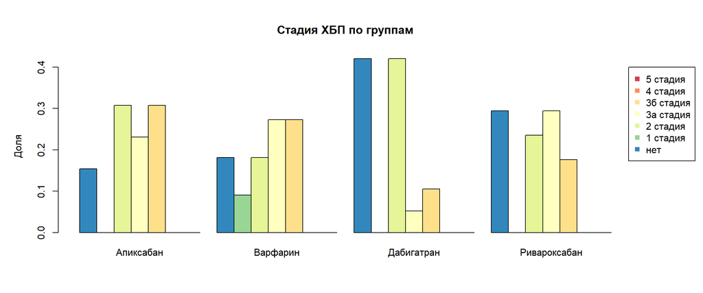

```r
par(mar = c(5,5,5,6))
barplot(table(first_visit_data$CKD_Stage1, first_visit_data$clear_drug) %>% prop.table(., 2),
        col = brewer.pal(n = first_visit_data$CKD_Stage1 %>% levels() %>% length, "Spectral") %>% rev(),
        main = "Стадия ХБП по группам",
        ylab = "Доля",
        beside = T
        )

legend(
  x = 33,
  y = 0.4,
  legend = levels(first_visit_data$CKD_Stage1) %>% rev(),
  col = brewer.pal(n = first_visit_data$CKD_Stage1 %>% levels() %>% length, "Spectral"),
  pch = 15,
  xpd = TRUE,
  inset = c(-0.50, 0)
)
```

```r
# names(first_visit_data)
```